# Fit and predict

Stef van Buuren

2017-05-06

## Objective

This vignette shows a step-by-step introduction of how to - Fit the broken stick model to data; - Predict observations by the fitted model.

## Get the data

```r
require("brokenstick")
require("hbgd")
require("rbokeh")
smc <- smocc_hgtwgt
```

## Calculate $Z$-scores

The broken stick model can fit observations in either the raw scale (cm, kg, and so on) or as a standard deviation score (SDS), or $Z$-score. The results from the analysis of the $Z$-score will often be better for two reasons: 1) for growth curves, a straight line assumption is more plausible in the $Z$-score scale, and 2) the assumption of normality is more plausible in the $Z$-score scale. It is easy to convert the measurements into the $Z$-score scale, fit the model, and convert back to the raw scale afterwards, if desired. The `hbgd` package contains several functions to convert back and forth between both scales. For example,

```r
haz <- who_htcm2zscore(smc$agedays, smc$htcm, smc$sex)
```

The main outcome measure will be `haz`, the age and sex-adjusted $Z$-score relative to the WHO growth standard. The inverse calculation can be done as

```r
htcm <- who_zscore2htcm(smc$agedays, haz, smc$sex)
```

Note that slight differences between `smc$htcm` and `htcm` may occur because of rounding, but the deviations are small and irrelevant.

[interactive chart not shown]

The mean $Z$-score is around 0.3, indicating that Dutch children under two years are taller than the WHO height standard.

The age range is 0-2 years. The scatterplot of height SDS by age clearly shows the pattern in the visits.

```r
figure(xlab = "Age (years)", ylab = get_label("haz")) %>%
  ly_zband(x = seq(0, 2.5, 0.5), z = -c(2.5,2,1,0)) %>%
  ly_points(smc$age, smc$haz, hover = c(smc$age, smc$htcm), size = 4)
```

[interactive chart not shown]

Note that the data contain some outliers. Child 10069 was born after a gestational age of 34 weeks and has several extremely low SDS values. Child 10075 had an observation at the age of 2.67 years.

The plot of the number of visits per child reveals that most children had 10 visits. It appears that children with fewer than six visits were removed from the data. Two children had more than 10 visits.

```r
plot_visit_distn(smc, width = 350, height = 350)
```

[interactive chart not shown]

The missing data plot shows that number of missing values in the time varying variables was very low.

```r
plot_missing(smc, width = 600, height = 400)
```

[interactive chart not shown]

## Define knots

The SMOCC study had 10 scheduled visits: at birth, and at ages of 1, 2, 3, 6, 9, 12, 15, 18 and 24 months. Here, we place the knots at the scheduled ages. Depending on the scientific question at hand, we could place knots at other locations. See the vignette on knot placement for more details.

```r
knots <- round(c(0, 1, 2, 3, 6, 9, 12, 15, 18, 24)/12, 4)
boundary <- c(0, 3)
```

## Fit the model

The `brokenstick` function performs the actual model fitting.

```r
fit <- brokenstick(y = smc$haz,
                   x = smc$age,
                   subjid = smc$subjid,
                   knots = knots,
                   boundary = boundary)
```

```
## Warning in commonArgs(par, fn, control, environment()): maxfun < 10 *
## length(par)^2 is not recommended.
```

```
## Warning in optwrap(optimizer, devfun, getStart(start, rho$lower, rho$pp), :
## convergence code 1 from bobyqa: bobyqa -- maximum number of function
## evaluations exceeded
```

```
## Warning in checkConv(attr(opt, "derivs"), opt$par, ctrl = control
## $checkConv, : unable to evaluate scaled gradient
```

```
## Warning in checkConv(attr(opt, "derivs"), opt$par, ctrl = control
## $checkConv, : Model failed to converge: degenerate Hessian with 1 negative
## eigenvalues
```

It frequently happens that the fitting algorithm issues warnings about the number of random effect (too high), or reports that one of the random effects is deleted before fitting. This may or nay not affect the quality of the predictions. At the least, the user should check the fitted object for plausibility. The current version uses the general purpose methods from the `lme4` package. Future versions of the `brokenstick` package may feature dedicated and stabler fitting methods that takes advantage of the special structure of the brokenstick model.

```r
class(fit)
```

```
## [1] "brokenstick"
```

The fitted object `fit` is of S4 class `brokenstick`, and extends class `lmerMod` with additional attributes `knots`, `boundary` and `degree`. The `brokenstick()` function only supports `degree = 1`, the straight line model.

## Interpret the model

Let us first extract the fixed effects and the corresponding knot locations.

```r
round(lme4::fixef(fit), 2)
```

```
##    x1    x2    x3    x4    x5    x6    x7    x8    x9   x10   x11
##  0.64  0.02 -0.17 -0.04  0.31  0.34  0.39  0.44  0.33  0.57  0.55
```

```r
round(get_knots(fit), 2)
```

```
##  [1] 0.00 0.08 0.17 0.25 0.50 0.75 1.00 1.25 1.50 2.00 3.00
```

The fixed effects correspond to the mean of sample of children in the data. The mean development over all 206 children may be plotted as:

```r
figure(xlab = "Age (years)", ylab = get_label("haz"), title = "Mean trajectory (n = 206)") %>%
  ly_zband(x = seq(0, 2.5, 0.5), z = -c(2.5,2,1,0)) %>%
  ly_points(get_knots(fit), lme4::fixef(fit), hover = c(get_knots(fit), lme4::fixef(fit))) %>%
  ly_lines(get_knots(fit), lme4::fixef(fit))
```

[interactive chart not shown]

```r
fit
```

```
## Linear mixed model fit by REML ['brokenstick']
## Formula: y ~ 0 + x1 + x2 + x3 + x4 + x5 + x6 + x7 + x8 + x9 + x10 + x11 +
##     (0 + x1 + x2 + x3 + x4 + x5 + x6 + x7 + x8 + x9 + x10 + x11 |
##         subjid)
##    Data: data
## REML criterion at convergence: 3338.95
## Random effects:
##  Groups   Name Std.Dev. Corr
##  subjid   x1   1.3632
##           x2   1.1845   0.77
##           x3   1.1668   0.76 0.90
##           x4   1.1097   0.72 0.89 0.90
##           x5   1.0019   0.51 0.77 0.77 0.83
##           x6   0.9858   0.51 0.63 0.64 0.75 0.92
##           x7   0.9387   0.43 0.59 0.56 0.64 0.91 0.92
##           x8   0.9763   0.37 0.56 0.52 0.60 0.81 0.87 0.95
##           x9   0.9905   0.36 0.54 0.56 0.60 0.82 0.86 0.91 0.95
##           x10  0.9696   0.32 0.45 0.46 0.55 0.74 0.79 0.85 0.90 0.90
##           x11  2.1430   0.19 0.34 0.16 0.14 0.02 0.12 0.14 0.37 0.29 0.24
##  Residual      0.2600
## Number of obs: 1960, groups:  subjid, 206
## Fixed Effects:
##       x1        x2        x3        x4        x5        x6        x7
##  0.64214   0.02438  -0.16508  -0.04292   0.30945   0.33851   0.39330
##       x8        x9       x10       x11
##  0.44049   0.33137   0.57175   0.54877
## convergence code 1; 2 optimizer warnings; 1 lme4 warnings
```

The column labeled `Std.Dev.` contains the standard deviations of the random effects. These numbers are expected to be around 1, since - under the assumption that the WHO standard appropriately describes this sample - the dependent variable follow a standard normal distribution with zero mean and standard deviation equal to one. The `Corr` component of the random effects lists the correlations between the broken stick estimates at different ages. The correlation matrix shows a typically pattern where the highest elements are close to the diagonal, and where off-diagonal elements decrease. The standard deviation of the residuals (within-person error) for this model is of 0.26, so on average, the discrepancy between observed and fitted trajectories is about one quarter of a standard deviation. At the age of 2 years, the standard deviation in height is about 32 mm, so on average the difference between the model and the observed data is about 8 mm, about twice the size of the technical error of measurement of a carefully conducted height measurement.

## Obtain predicted values, all children

The `predict()` function obtains predictions from the broken stick model. The function is extremely flexible, and allows for prediction of new subjects at arbitrary ages in a variety of output formats. The simplest call

```r
p1 <- predict(fit)
head(p1, 4)
```

```
##   subjid      x     y      yhat  knot
## 1  10001 0.0000 1.531 1.5236922 FALSE
## 2  10001 0.0821 1.007 0.9876856 FALSE
## 3  10001 0.1588 0.700 0.6506504 FALSE
## 4  10001 0.2546 0.598 0.5835480 FALSE
```

produces the predicted value (in `yhat`) for each measured data point for all children used to fit the model in the `long` output format. The observed $Z$-score is stored in column called `y`, and the corresponding broken stick estimates are stored in the column called `yhat`. The column `knot` is set to `FALSE` if `y` is actually observed.

The predicted values represent a compromise between the person’s data values and the global mean. In general, the fewer and less extreme data points of a person are, the closer the compromise will be toward the global mean. The compromise is called the *conditional mean* of the posterior distribution. In the broken stick model, it is simply calculated as the sum of the fixed and random effects.

We can obtain the locations at which the lines connect by specifying the `at = "knots"` argument, e.g.

```r
p2 <- predict(fit, at = "knots")
head(p2, 4)
```

```
##   subjid      x  y      yhat knot
## 1  10001 0.0000 NA 1.5236922 TRUE
## 2  10001 0.0833 NA 0.9798511 TRUE
## 3  10001 0.1667 NA 0.6162042 TRUE
## 4  10001 0.2500 NA 0.5835202 TRUE
```

```r
p3 <- predict(fit, at = "both")
head(p3, 4)
```

```
##   subjid      x     y      yhat  knot
## 1  10001 0.0000 1.531 1.5236922 FALSE
## 2  10001 0.0821 1.007 0.9876856 FALSE
## 3  10001 0.1588 0.700 0.6506504 FALSE
## 4  10001 0.2546 0.598 0.5835480 FALSE
```

The first three fitted trajectories are plotted by

```r
plot(fit, height = 300, size.y = 4, size.yhat = 4, x_trim = c(0, 2.2), show_reference = TRUE)
```

[interactive chart not shown]

## Obtain predicted values, single child

The computationally fastest way to obtain predicted values for just one subject from a fitted model is to specify the `ids`, `at` and `output` arguments as

```r
p1 <- predict(fit, ids = 10001, at = "knots", output = "vector")
```

The `predict()` function can return additional information by altering these arguments. Type `?predict.brokenstick` at the console to see the documentation.

## Plot a subset of children

We plot the original data and the broken stick estimates for child 10001 jointly as

```r
plot(fit, ids = 10001, x_trim = c(0, 2.2), show_reference = TRUE)
```

[interactive chart not shown]

## Convert to original scale

Modeling was done in the $Z$-score scale for the reasons given above. We may plot the result in the original scale by back-converting the estimates using the WHO reference, as follows:

```r
# convert Z-score to CM
p <- predict(fit, ids = 10001, at = "both")
p$ycm <- round(who_zscore2htcm(years2days(p$x), p$y, sex = "Female"), 1)
p$yhatcm <- who_zscore2htcm(years2days(p$x), p$yhat, sex = "Female")
head(p)
```

```
##         subjid      x     y      yhat  knot  ycm   yhatcm
## 10001.1  10001 0.0000 1.531 1.5236922 FALSE 52.0 51.98588
## 10001.2  10001 0.0821 1.007 0.9876856 FALSE 55.6 55.55965
## 10001.3  10001 0.1588 0.700 0.6506504 FALSE 58.2 58.10055
## 10001.4  10001 0.2546 0.598 0.5835480 FALSE 61.2 61.16967
## 10001.5  10001 0.5038 0.615 0.5792703 FALSE 67.2 67.11864
## 10001.6  10001 0.7529 0.004 0.2103246 FALSE 70.2 70.69939
```

The corresponding figure in the cm scale can be produced as

```r
p <- p[p$x <= 2.5,]
figure(xlab = "Age (years)", ylab = get_label("htcm")) %>%
  ly_who(x = seq(0, 750, by = 30), y_var = "htcm",
    x_trans = days2years, sex = "Female", color = "green",
    p = 100 * pnorm(-c(2.5,2,1,0))) %>%
  ly_points(p$x, p$ycm) %>%
  ly_lines(p$x[p$knot], p$yhatcm[p$knot], col = "orangered") %>%
  ly_points(p$x[p$knot], p$yhatcm[p$knot], col = "orangered", size = 6)
```

[interactive chart not shown]

## Export and publish model

A brokenstick model like in `fit` can be stored by `save()` for future use in R. However, this is a fairly large object that contains a lot of superfluous information. As a matter of fact, if we know the `x` and `y` variables of a given person, prediction using the broken stick model requires only the knot locations, the fixed effect estimates, the variance/covariance matrix of the random effects, and the size of the residual variance. The `export()` function will collect this information from the fitted model, and store it as a list.

```r
# export the broken stick models
exp <- export(fit)
attributes(exp)
```

```
## $names
## [1] "beta"     "omega"    "sigma2"   "knots"    "boundary" "degree"
##
## $class
## [1] "brokenstick_export"
```

```r
lapply(exp, round, 2)
```

```
## $beta
##    x1    x2    x3    x4    x5    x6    x7    x8    x9   x10   x11
##  0.64  0.02 -0.17 -0.04  0.31  0.34  0.39  0.44  0.33  0.57  0.55
##
## $omega
##       x1   x2   x3   x4   x5   x6   x7   x8   x9  x10  x11
## x1  1.86 1.25 1.21 1.09 0.70 0.68 0.55 0.49 0.48 0.42 0.56
## x2  1.25 1.40 1.24 1.17 0.91 0.74 0.65 0.64 0.63 0.52 0.87
## x3  1.21 1.24 1.36 1.17 0.90 0.74 0.61 0.59 0.65 0.52 0.40
## x4  1.09 1.17 1.17 1.23 0.92 0.82 0.67 0.66 0.66 0.59 0.32
## x5  0.70 0.91 0.90 0.92 1.00 0.91 0.85 0.80 0.82 0.72 0.05
## x6  0.68 0.74 0.74 0.82 0.91 0.97 0.85 0.83 0.84 0.75 0.26
## x7  0.55 0.65 0.61 0.67 0.85 0.85 0.88 0.87 0.84 0.77 0.28
## x8  0.49 0.64 0.59 0.66 0.80 0.83 0.87 0.95 0.92 0.85 0.78
## x9  0.48 0.63 0.65 0.66 0.82 0.84 0.84 0.92 0.98 0.87 0.62
## x10 0.42 0.52 0.52 0.59 0.72 0.75 0.77 0.85 0.87 0.94 0.49
## x11 0.56 0.87 0.40 0.32 0.05 0.26 0.28 0.78 0.62 0.49 4.59
##
## $sigma2
## [1] 0.07
##
## $knots
## [1] 0.08 0.17 0.25 0.50 0.75 1.00 1.25 1.50 2.00
##
## $boundary
## [1] 0 3
##
## $degree
## [1] 1
```

This set of estimates represents a longitudinal growth reference, and can be published as such.

## Predict from the published model

Suppose we have measured a new boy, say Fred. We wish to obtain predictions for Fred using the exported model in `exp`. The following code calculates these predictions.

```r
# Five age-haz observations for Fred
x <- c(0, 0.12, 0.32, 0.62, 1.1)
y <- c(-1.2, -1.8, -1.7, -1.9, -2.1)
predict(exp, y, x, at = "both", subjid = "Fred")
```

```
##    subjid      x    y       yhat  knot
## 1    Fred 0.0000 -1.2 -1.1669224 FALSE
## 2    Fred 0.1200 -1.8 -1.7895415 FALSE
## 3    Fred 0.3200 -1.7 -1.7694903 FALSE
## 4    Fred 0.6200 -1.9 -1.8632483 FALSE
## 5    Fred 1.1000 -2.1 -1.9280928 FALSE
## 12   Fred 0.0000   NA -1.1669224  TRUE
## 21   Fred 0.0833   NA -1.7667613  TRUE
## 31   Fred 0.1667   NA -1.8185288  TRUE
## 41   Fred 0.2500   NA -1.7449832  TRUE
## 51   Fred 0.5000   NA -1.8325086  TRUE
## 6    Fred 0.7500   NA -1.8965495  TRUE
## 7    Fred 1.0000   NA -1.9282027  TRUE
## 8    Fred 1.2500   NA -1.9279279  TRUE
## 9    Fred 1.5000   NA -1.9465447  TRUE
## 10   Fred 2.0000   NA -1.5154081  TRUE
## 11   Fred 3.0000   NA -0.8856439  TRUE
```

Thus, based on the data up to 1.1 year, the model predicts that Fred’s growth curve would remain around -2.0 SD until Fred is 1.5 years, and then would increase to -1.5 SD.

## Predict values, all children in the model

If we have access to the `brokenstick` object, prediction of cases used in the fitting process is straightforward.

```r
# if we have access to the brokenstick object
p <- predict(fit)
head(p, 3)
```

```
##   subjid      x     y      yhat  knot
## 1  10001 0.0000 1.531 1.5236922 FALSE
## 2  10001 0.0821 1.007 0.9876856 FALSE
## 3  10001 0.1588 0.700 0.6506504 FALSE
```

The `brokenstick_export` object does not store the individual data, but if we have the data stored in another place (here `smc`), we may obtain predictions as follows:

```r
# case-by-case prediction on external data
ds <- split(smc, f = smc$subjid, drop = TRUE)
result <- vector("list", length(ds))
for (i in seq_along(ds)) {
  d <- ds[[i]]
  if (nrow(d) > 0) result[[i]] <- predict(exp, y = d$haz, x = d$age, subjid = d$subjid[1])
}
result <- do.call(rbind, result)
row.names(result) <- 1:nrow(result)

# check that we get the same answers
all.equal(result, p)
```

```
## [1] TRUE
```

## Assess quality of prediction ($Z$-scale)

The scatterplot of the observed versus predicted values indicates an extremely accurate prediction.

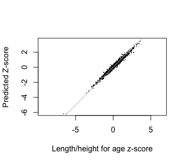

The correlation is to 0.9895. The standard deviation of the residuals is equal to 0.163, a small value in the $Z$-scale.

## Assess quality of prediction (cm scale)

When back-converted to centimeters, the scatterplot of the observed versus predicted values is even a little tighter.

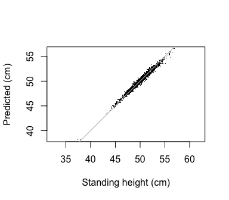

The correlation is to 0.99. The standard deviation of the residuals is equal to 0.307 cm, which is very small.